# Esercitazione N.1

Regressione Lineare Semplice

Autore/Autrice

Andrea Recine

Data di Pubblicazione

28 aprile 2026

## 1 Introduzione

```r
library(tidyverse)
library(knitr)
library(tinytable)
library(modelsummary)
```

`library(tidyverse)` contiene diversi pacchetti tra cui:

- dplyr (gestione dati)
- tidyr (riorganizzazione dei dati)
- ggplot2 (grafici)
- readr (importazione CSV e altro)

In alternativa caricate i pacchetti singolarmente: `library(ggplot2)` o `library(dplyr)`

Le altre librerie come `library(knitr)`, `library(tinytable)`e `library(modelsummary)` sono utili per creare tabelle e visualizzare i risultati delle regressioni in modo più chiaro e formattato.

## 2 Descrizione dei dati

```r
library(wooldridge)
```

Consideriamo il dataset **wage1** in `library(wooldridge)` tratto dalla Current Population Survey del 1976 e guardiamo la struttura usando `head(wage).`

```r
data("wage1", package = "wooldridge")
head(wage1)
```

```
#>   wage educ exper tenure nonwhite female married numdep smsa northcen south
#> 1 3.10   11     2      0        0      1       0      2    1        0     0
#> 2 3.24   12    22      2        0      1       1      3    1        0     0
#> 3 3.00   11     2      0        0      0       0      2    0        0     0
#> 4 6.00    8    44     28        0      0       1      0    1        0     0
#> 5 5.30   12     7      2        0      0       1      1    0        0     0
#> 6 8.75   16     9      8        0      0       1      0    1        0     0
#>   west construc ndurman trcommpu trade services profserv profocc clerocc
#> 1    1        0       0        0     0        0        0       0       0
#> 2    1        0       0        0     0        1        0       0       0
#> 3    1        0       0        0     1        0        0       0       0
#> 4    1        0       0        0     0        0        0       0       1
#> 5    1        0       0        0     0        0        0       0       0
#> 6    1        0       0        0     0        0        1       1       0
#>   servocc    lwage expersq tenursq
#> 1       0 1.131402       4       0
#> 2       1 1.175573     484       4
#> 3       0 1.098612       4       0
#> 4       0 1.791759    1936     784
#> 5       0 1.667707      49       4
#> 6       0 2.169054      81      64
```

Consideriamo le seguenti variabili:

- $wage$ retribuzione media oraria in dollari del 1976
- $educ$ anni di istruzione

```r
# Statistiche descrittive
stat <- wage1 %>%
       summarise(
       wage_mean = mean(wage, na.rm = TRUE),
       wage_median = median(wage, na.rm = TRUE),
       wage_sd = sd(wage, na.rm = TRUE),
       education_years_mean = mean(educ, na.rm = TRUE),
       education_years_median = median(educ, na.rm = TRUE)
  )
# Visualizzazione dei risultati
tt(stat, width = 1, digits = 2, caption = "Statistiche descrittive")
```

Statistiche descrittive

| wage_mean | wage_median | wage_sd | education_years_mean | education_years_median |
| --- | --- | --- | --- | --- |
| 5.9 | 4.7 | 3.7 | 13 | 12 |

- `summarise` riassume i dati
- `%>%` o `>|` (a partire da R 4.1.0) è l’operatore “pipe” per concatenare operazioni multiple.
- `tt()` è una funzione del pacchetto `tinytable` per visualizzare tabelle in modo più chiaro e formattato.

Un’altra libreria utile per gestire i dati è `library(data.table)`, e per formattare le tabelle è `library(kableExtra)`.

`ggplot2` e basato sulla “Grammatica dei Grafici” (gg = *grammar of graphics*). Consente di generare grafici attraverso un approccio a strati con il simbolo “+” e risulta molto più flessibile per grafici complessi e personalizzabile rispetto a grafici base di R.

Se non avete caricato `library(tidyverse)` allora dovete usare `library(ggplot2)`.

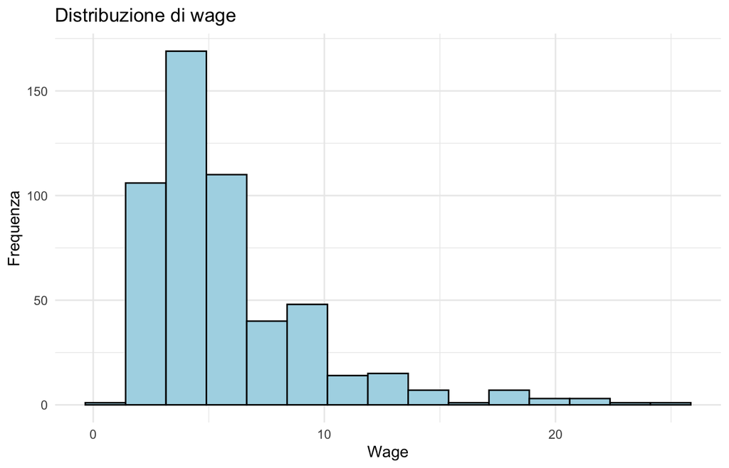

```r
# Istogramma con ggplot
ggplot(wage1, aes(x = wage)) +
geom_histogram(fill = "lightblue", color = "black", bins = 15) +
labs(title = "Distribuzione di wage",
x = "Wage",
y = "Frequenza") +
theme_minimal()
```

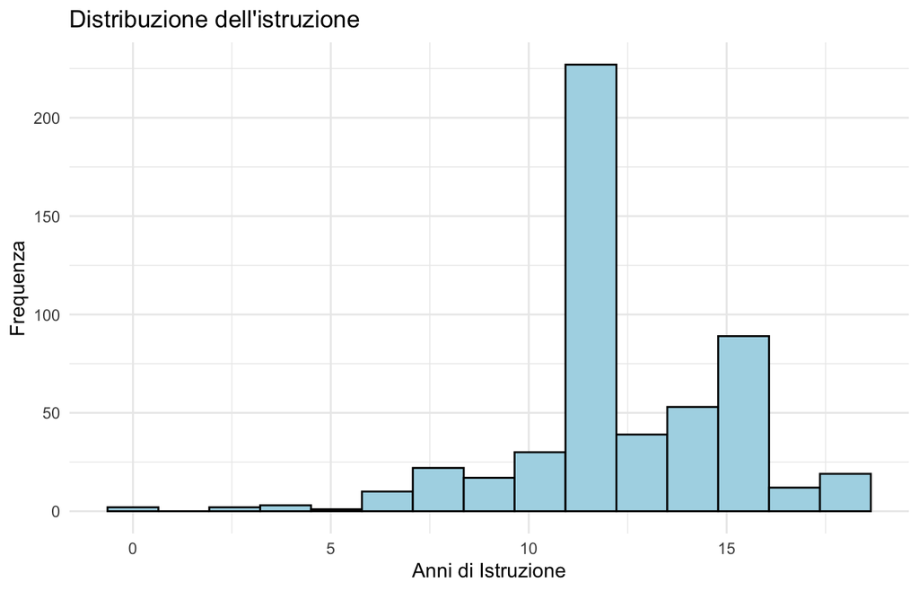

```r
# Istogramma con ggplot2
ggplot(wage1, aes(x = educ)) +
geom_histogram(fill = "lightblue", color = "black", bins = 15) +
labs(title = "Distribuzione dell'istruzione",
x = "Anni di Istruzione",
y = "Frequenza") +
theme_minimal()
```

L’istogramma mostra una concentrazione elevata intorno ai 12 anni di istruzione, che corrispondono al diploma di scuola superiore (high school) negli USA.

### 2.1 Relazione tra salario orario e anni di istruzione:

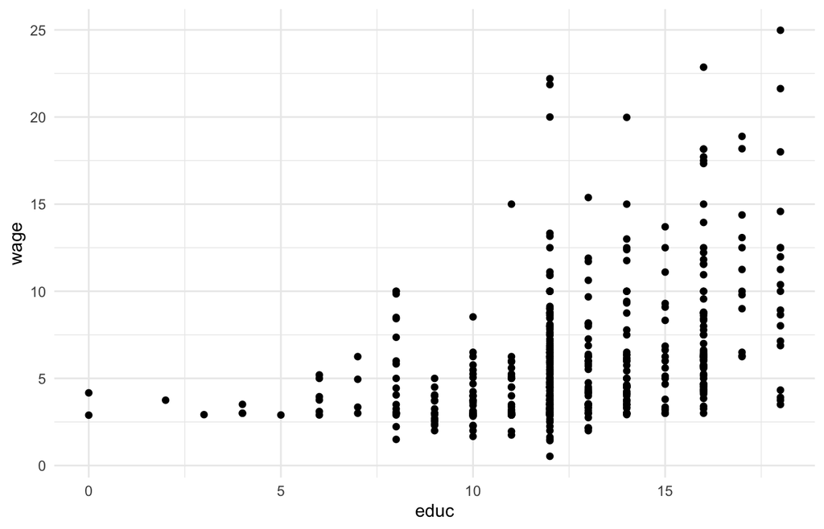

```r
ggplot(wage1, aes(y = wage, x = educ)) +
  geom_point(color = "black") +
  theme_minimal()
```

Con la retta di regressione:

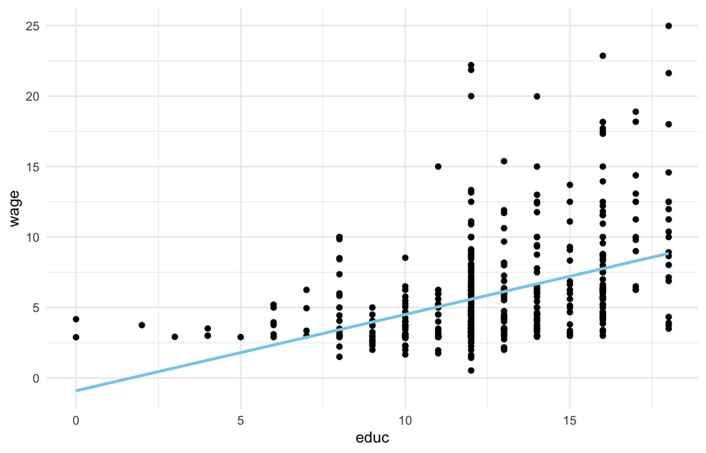

```r
## Secondo Grafico
ggplot(wage1, aes(y = wage, x = educ)) +
  geom_point(color = "black") +
  geom_smooth(method = "lm", color = "skyblue", se = FALSE) +
  theme_minimal()
```

`lm` sta per linear model

## 3 Regressione lineare semplice

Stimiamo la seguente regressione:

$$wage_i = \beta_0 + \beta_1 educ_i + u_i$$

$wage$ è misurato in dollari per ora and $educ$ sono gli anni di istruzione.

`library(fixest)` è una libreria molto versatile soprattutto per dati panel e permette di correggere facilmente gli errori standard usando `vcov = "hetero"` o `vcov = "hc1"`.

In altri corsi potreste aver visto la regressione stimata con `lm(y~x)`. In questo caso, l’output della regressione riporta errori standard omoschedastici che possono essere corretti utilizzando `library(sandwich)` con la funzione `vcovHC()`.

Nel resto del corso useremo `library(fixest)` per stimare le regressioni e correggere gli errori standard all’eteroschedasticità.

```r
# Modello di regressione base
library(fixest)
reg1 <- feols(wage ~ educ, data = wage1, vcov = "hetero")
reg1
```

```
#> OLS estimation, Dep. Var.: wage
#> Observations: 526
#> Standard-errors: Heteroskedasticity-robust
#>              Estimate Std. Error  t value  Pr(>|t|)
#> (Intercept) -0.904852   0.725479 -1.24725   0.21286
#> educ         0.541359   0.061260  8.83713 < 2.2e-16 ***
#> ---
#> Signif. codes:  0 '***' 0.001 '**' 0.01 '*' 0.05 '.' 0.1 ' ' 1
#> RMSE: 3.37196   Adj. R2: 0.163164
```

- `feols()` stima la regressione lineare
- $wage$ è la variabile dipendente,
- $educ$ è la variabile indipendente (o regressore)
- `vcov = "hetero"`seleziona errori standard robusti all’eteroschedasticità

Se non si sceglie `vcov = "hetero"`, gli errori saranno omoschedastici:

```r
reg1_ho <- feols(wage ~ educ, data = wage1)
reg1_ho
```

```
#> OLS estimation, Dep. Var.: wage
#> Observations: 526
#> Standard-errors: IID
#>              Estimate Std. Error  t value  Pr(>|t|)
#> (Intercept) -0.904852   0.684968 -1.32101   0.18707
#> educ         0.541359   0.053248 10.16675 < 2.2e-16 ***
#> ---
#> Signif. codes:  0 '***' 0.001 '**' 0.01 '*' 0.05 '.' 0.1 ' ' 1
#> RMSE: 3.37196   Adj. R2: 0.163164
```

`feols(y ~ x)` sarà equivalente a `lm(y ~ x)`

L’output della regressione riporta errori standard *IID* (indipendenti e identicamente distribuiti) che sono omoschedastici.

### 3.1 Eteroschedasticità

La prima assunzione per avere stima non distorta è che $E(u_i|educ_i)=0$

**ConsiglioDomanda**

Quali sono le altre assunzioni di OLS per l’inferenza causale?

In popolazione implica che $E(wage_i|educ_i)= \beta_0 + \beta_1 educ_i$.

Assumendo omoschedasticità, cioè $Var(u_i|educ_i)= \sigma^2$ è equivalente, in popolazione, ad assumere $Var(wage_i|educ_i) = \sigma^2$.

Mentre il valore atteso di $wage$ può aumentare al crescere degli anni di istruzione (ed è ciò a cui siamo interessati), sotto omoschedasticità la varianza di $wage$ non cambia al variare di $educ$. Cioè, stiamo assumendo che la varianza del salario condizionata all’istruzione sia costante.

Questo non è realistico. Persone con più istruzione hanno una varietà maggiore di opportunità di lavoro e interessi, che porta maggiore variabilità di $wage$ ai livelli più alti di istruzione. Persone con un basso livello di istruzione hanno minori opportunità e spesso $wage$ vicino al salario minimo. Questo tende a ridurre la variabilità di $wage$ nei livelli più bassi di istruzione.

Quando $Var(u_i|x_i)$ dipende da $x_i$, il termine d’errore mostra eteroschedasticità (varianza non costante). Poiché $Var(u_i|x)=Var(y|x)$, l’eteroschedasticità è presente ogni volta che $Var(y_i|x_i)$ è una funzione di $x_i$

**AttenzioneImplicazioni dell’eteroschedasticità**

Le assunzioni OLS non pongono restrizioni sulla varianza condizionata. Perciò, gli stimatori OLS rimangono non distorti, consistenti e asintonticamente normali anche in presenza di eteroschedasticità.

I test di ipotesi e gli intervalli di confidenza basati su errori standard robusti all’eteroschedasticità sono validi indipendentemente dalla struttura della varianza degli errori permettendo inferenza statistica valida anche in presenza di eteroschedasticità. Tali formule sono state proposte da Eicker (1967), Huber (1967) e White (1980) e sono comunemente note come errori standard di Eicker-Huber-White (a volte solo White) o errori standard robusti.

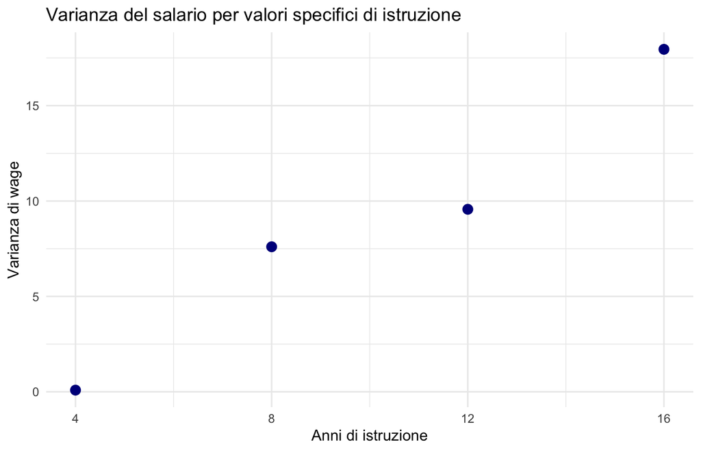

```r
# Seleziona valori specifici di educ
educ_valori <- c(4, 8, 12, 16)

# Calcola varianza di wage per quei valori specifici di educ
varianza_valori <- wage1 %>%
  filter(educ %in% educ_valori) %>%
  group_by(educ) %>%
  summarise(varianza = var(wage, na.rm = TRUE)) %>%
  ungroup()

# Grafico
ggplot(varianza_valori, aes(x = educ, y = varianza)) +
  geom_point(size = 3, color = "darkblue") +
  labs(title = "Varianza del salario per valori specifici di istruzione",
       x = "Anni di istruzione",
       y = "Varianza di wage") +
  theme_minimal()
```

- `group_by` raggruppa i dati per categorie

Ora proviamo a raggruppare usando 10 gruppi di livelli di istruzione:

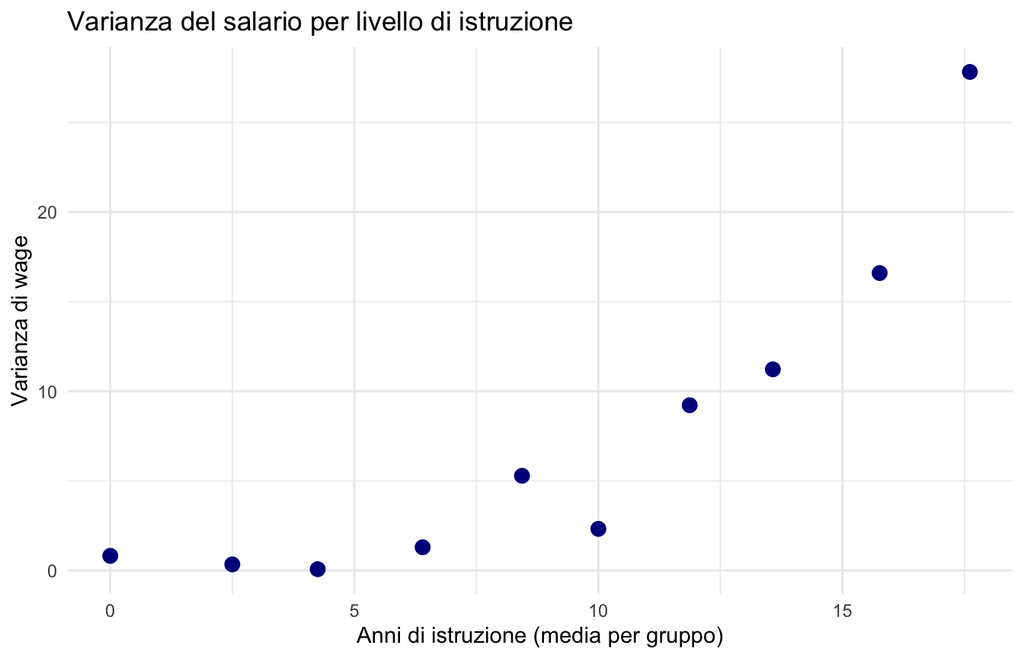

```r
# 1. Raggruppa educ in intervalli
varianza_educ <- wage1 %>%
  mutate(gruppo_educ = cut(educ, breaks = 10)) %>%
  group_by(gruppo_educ) %>%
  summarise(
    varianza = var(wage, na.rm = TRUE),
    media_educ = mean(educ, na.rm = TRUE)
  )

# 2. Grafico della varianza in funzione di educ
ggplot(varianza_educ, aes(x = media_educ, y = varianza)) +
  geom_point(size = 3, color = "darkblue") +
  labs(title = "Varianza del salario per livello di istruzione",
       x = "Anni di istruzione (media per gruppo)",
       y = "Varianza di wage") +
  theme_minimal()
```

#### 3.1.1 Risultati della regressione

```r
modelsummary(list("Wage" = reg1, "Wage" = reg1_ho), gof_omit = "AIC|BIC|RMSE|R2 Adj.")
```

Risultati stima OLS. Variabile dipendente $:$ Wage

|  | Wage | Wage |
| --- | --- | --- |
| (Intercept) | -0.905 | -0.905 |
|  | (0.725) | (0.685) |
| educ | 0.541 | 0.541 |
|  | (0.061) | (0.053) |
| Num.Obs. | 526 | 526 |
| R2 | 0.165 | 0.165 |

Il valore dell’intercetta è -0.90. Rappresenta il salario orario medio stimato in dollari per una persona con zero anni di istruzione. Questa interpretazione ha scarso significato. Infatti, è il valore atteso quando $educ=0$, cioè per una persona senza alcuna istruzione formale, che potrebbe essere un caso raro o non rappresentativo nella popolazione.

Il coefficiente di educ $\beta_1$ rappresenta l’incremento medio del salario orario **associato** ad un anno in più di istruzione.

Se $E(u_i|educ_i)=0$ allora $\beta_1 = 0.54$ ha un’interpretazione causale: un anno in più di istruzione aumenta, in media, il salario orario di 0.54$ per ora. In caso contrario 0.54$ è una semplice correlazione.

Se volessi considerare 10 anni in più di istruzione: 10 x $\beta_1$ = 10 x 0.54$ = 5.4 dollari per ora.

Esistono variabili che influenzano contemporaneamente sia il salario ($wage$) che gli anni di istruzione ($educ$). Quando queste variabili sono nell’errore, creano correlazione tra $u_i$ e $educ_i$, violando così l’assunzione $E(u_i|educ_i)=0$.

Quali potrebbero essere le variabili che influenzano $wage$ e $educ$? Possono essere osservabili (ad esempio esperienza, background familiare, settore occupazionale) e variabili che invece non possiamo osservare (ad esempio abilità innate, connessioni sociali).

Queste variabili omesse creano un problema di endogeneità che rende difficile interpretare $\beta_1$ come l’effetto causale dell’istruzione sul salario, poiché la correlazione osservata potrebbe essere in parte dovuta a questi fattori confondenti.

$R^2$ indica che circa il 16,5% della variabilità di $wage$ è spiegata da $educ$. Questo valore relativamente basso suggerisce **soltanto** che esistono molti altri fattori oltre all’istruzione che sono correlati con i salari.

**Avviso$R^2$**

L’$R^2$ della regressione è la frazione della varianza campionaria di $Y_i$ spiegata dai regressori.

Ricordate che:

- Un $R^2$ elevato non implica che i regressori siano la vera “causa” della variabile dipendente
- Un $R^2$ elevato non implica che non vi sia distorsione da variabili omesse
- Un $R^2$ elevato non significa che abbiamo scelto i regressori più appropriati
- Un $R^2$ basso non implica che abbiamo scelto regressori inappropriati

**AttenzioneTeoria asintotica e normalità degli errori**

La normalità degli errori **non** è necessaria né per la non distorsione di OLS, né per la proprietà di essere il miglior stimatore lineare non distorto (BLUE) sotto le assunzioni di Gauss-Markov (che richiedono omoschedasticità).

In alcuni corsi potete aver visto testare la “normalità” dei residui come condizione *necessaria* per procedere a una inferenza corretta (“validare il modello”). In realtà, l’assunzione è sugli errori nella popolazione che non osserviamo! Quindi i test sulla normalità degli errori (e.g., Test di Jarque-Bera) si basano sui residui OLS. Nella pratica questo test si fa raramente. Infatti, grazie al teorema del limite centrale, quando il campione è “sufficientemente grande”, la distribuzione asintotica degli stimatori OLS è normale anche se gli errori nella popolazione non si distribuiscono normalmente.

## 4 Cambio di unità di misura

I coefficienti di regressione, sono nell’unità di misura dei dati. Il valore dei coefficienti cambia se cambiamo l’unità di misura, mentre l’adattamento del modello ai dati non cambia. Vediamo come cambiano i coefficienti se cambiamo l’unità di misura di $wage$ e $educ$.

### 4.1 Variabile dipendente: wage

**Salario orario in centinaia di dollari:** $wage$ è espresso in dollari. Possiamo esprimerlo in centinaia di dollari:

```r
wage1 <- wage1 %>%
  mutate(wage_100 = wage/100)
```

- `mutate` crea o modifica variabili

```r
reg2 <- feols(wage_100 ~ educ, data = wage1, vcov = "hetero")
modelsummary(list("Wage" = reg1, "Wage centinaia di $" = reg2), gof_omit = "AIC|BIC|RMSE|R2 Adj.")
```

|  | Wage | Wage centinaia di $ |
| --- | --- | --- |
| (Intercept) | -0.905 | -0.009 |
|  | (0.725) | (0.007) |
| educ | 0.541 | 0.005 |
|  | (0.061) | (0.001) |
| Num.Obs. | 526 | 526 |
| R2 | 0.165 | 0.165 |

In media, un anno aggiuntivo di istruzione è associato ad un aumento del salario orario di 0.005 centinaia di dollari. Che sarebbero 0.005 $\times$ 100 $\approx$ 0.5 dollari (0.541 senza arrotondamento).

**Salario mensile:** Supponiamo lavoratori a tempo pieno, 7 ore al giorno, 5 giorni a settimana, 4 settimane al mese. Cioè 7 $\times$ 5 $\times$ 4 = 140

Creiamo una nuova variabile wage_monthly = $wage$ $\times$ 140

```r
wage1 <- wage1 %>%
  mutate(wage_monthly = wage*140)
```

Nuova regressione:

```r
reg3 <- feols(wage_monthly ~ educ, data = wage1, vcov = "hetero")
reg3
```

```
#> OLS estimation, Dep. Var.: wage_monthly
#> Observations: 526
#> Standard-errors: Heteroskedasticity-robust
#>              Estimate Std. Error  t value  Pr(>|t|)
#> (Intercept) -126.6792  101.56713 -1.24725   0.21286
#> educ          75.7903    8.57635  8.83713 < 2.2e-16 ***
#> ---
#> Signif. codes:  0 '***' 0.001 '**' 0.01 '*' 0.05 '.' 0.1 ' ' 1
#> RMSE: 472.1   Adj. R2: 0.163164
```

Confrontiamo le due regressioni:

```r
modelsummary(
  list("Wage Hourly" = reg1, "Wage Monthly" = reg3), gof_omit = "AIC|BIC|RMSE|R2 Adj."
)
```

|  | Wage Hourly | Wage Monthly |
| --- | --- | --- |
| (Intercept) | -0.905 | -126.679 |
|  | (0.725) | (101.567) |
| educ | 0.541 | 75.790 |
|  | (0.061) | (8.576) |
| Num.Obs. | 526 | 526 |
| R2 | 0.165 | 0.165 |

I coefficienti del secondo modello sono pari a quelli del primo modello $\times$ 140. Lo stesso per gli errori standard.

In media, un anno aggiuntivo di istruzione è **associato** ad un aumento del salario mensile di 75.79 dollari.

75.79 dollari = 0.541 $\times$ 140

### 4.2 Variabile indipendente: educ

Supponiamo che $educ$ sia in mesi di istruzione. Cioè $educ$ $\times$ 12:

```r
wage1 <- wage1 %>%
  mutate(educ_mesi = educ*12)
```

```r
reg4 <- feols(wage ~ educ_mesi, data = wage1, vcov = "hetero")
modelsummary(list("Wage" = reg1, "Wage" = reg4), gof_omit = "AIC|BIC|RMSE|R2 Adj.")
```

|  | Wage | Wage |
| --- | --- | --- |
| (Intercept) | -0.905 | -0.905 |
|  | (0.725) | (0.725) |
| educ | 0.541 |  |
|  | (0.061) |  |
| educ_mesi |  | 0.045 |
|  |  | (0.005) |
| Num.Obs. | 526 | 526 |
| R2 | 0.165 | 0.165 |

In questo caso l’intercetta **non** cambia. Il valore dell’intercetta è -0.90 rappresenta il salario orario stimato medio in dollari per una persona con zero mesi di istruzione.

In media, un mese aggiuntivo di istruzione è **associato** ad un aumento del salario orario di 0.045 dollari $0.045 = \frac{0.541}{12}$.

**ImportanteBontà di adattamento e unità di misura**

Il cambiamento di unità di misura, sia della variabile dipendente che di quella indipendente, non cambia la bontà di adattamento del modello ai dati. L’$R^2$ rimane invariato, così come la significatività statistica dei coefficienti (il rapporto tra coefficiente e errore standard rimane lo stesso).

**Attenzione (1)** quando vedremo modelli con variabile dipendente in forma logaritmica. In quel caso -come vedremo- se confrontiamo due modelli: uno dove la variabile dipendente è $wage$ e uno dove è $log(wage)$, stiamo confrontando due modelli diversi (lin-lin vs log-lin).

**Attenzione (2)** a cambiamenti nell’unità di misura quando le variabile dipendente è espressa in forma logaritmica come vedremo successivamente.

## 5 Intervalli di confidenza e test di ipotesi

Consideriamo la prima regressione:

```r
modelsummary(list("Wage Hourly" = reg1), gof_omit = "AIC|BIC|RMSE|R2 Adj.")
```

|  | Wage Hourly |
| --- | --- |
| (Intercept) | -0.905 |
|  | (0.725) |
| educ | 0.541 |
|  | (0.061) |
| Num.Obs. | 526 |
| R2 | 0.165 |

L’intervallo di confidenza al 95% per $\beta_1$ si calcola come:

$$\beta_1 \pm z_{1-\alpha/2} \times SE(\beta_1)
\tag{1}$$

Dove $z_{1-\alpha/2}$ è il valore critico della distribuzione normale standard: per $\alpha = 0.05$, abbiamo $z_{0.975} = 1.96$.

Sostituendo i valori del coefficiente e dell’errore standard:
$$\beta_1 \pm 1.96 \times SE(\beta_1) \implies 0.541 \pm 1.96 \times 0.061 \implies
0.541 \pm 0.119$$

Con una confidenza del 95%, possiamo affermare che il vero valore del coefficiente $\beta_1$ è compreso nell’intervallo tra 0.422 e 0.66 dollari.

Usando `feols()` e `confint`

```r
confint(reg1)
```

```
#>                  2.5 %    97.5 %
#> (Intercept) -2.3300571 0.5203539
#> educ         0.4210146 0.6617039
```

Ipotesi nulla e alternativa:

$$H_0: \beta_1 = 0 \quad \text{(nessun associazione fra wage e educ)}$$

$$H_1: \beta_1 \neq 0 \quad \text{(esiste un'associazione fra wage e educ)}$$

Per costruire il test, iniziamo calcolando la statistica $z$:

$$z = \frac{\beta_1}{SE(\beta_1)} = \frac{0.541}{0.061} = 8.87$$

Poi confrontiamo il valore critico $z_{0.975} = 1.96$ con il valore assoluto di $z$. Possiamo rifiutiare l’ipotesi nulla se $|z|$ è maggiore di 1.96. Nel caso opposto, $|z|$ minore di 1.96, non possiamo rifiutare l’ipotesi nulla.

Nel nostro caso:
$$|z| = 8.87 > 1.96$$

quindi rifiutiamo l’ipotesi nulla $H_0$ al livello di significatività del 5%. Di conseguenza, possiamo affermare che il coefficiente $\beta_1$ è *statisticamente significativo* al livello del 5% che significa che abbiamo evidenza statistica per concludere che esiste un’associazione tra $educ$ e $wage$.

L’intervallo di confidenza per 2 anni di istruzione in più sarebbe:

$$2 \times 0.541 \pm 1.96 \times 2 \times 0.061 \implies
1.082 \pm 0.238$$

Che equivale a moltiplicare per 2 gli estremi dell’intervallo di confidenza per un anno di istruzione.

## 6 Intervalli di confidenza e cambio di unità di misura

Abbiamo appena visto che:

$$\beta_1 \pm 1.96 \times SE(\beta_1) \implies 0.541 \pm 1.96 \times 0.061 \implies
0.541 \pm 0.119$$

Se $wage$ fosse espresso in centinaia di dollari, l’intervallo di confidenza per $\beta_1$ sarebbe:

$$\frac{0.541}{100} \pm 1.96 \times \frac{0.061}{100} \implies 0,00541 \pm 1.96 \times 0.00061 \implies 0.00541 \pm 0.00119$$

Che equivale a dividere per 100 gli estremi dell’intervallo di confidenza espresso in dollari.

## 7 Variabili dummy

Le *variabili dummy* sono uno strumento necessario per incorporare informazioni categoriche in modelli di regressione.

Consideriamo una variabile categorica `female` (che indica il genere del lavoratore). La variabile può prendere soltanto due valori `Femmina` e `Maschio`. La variabile dummy sarà uguale a:

```r
tabledummy <- table(wage1$female)
names(tabledummy) <- c("Male", "Female")

as.data.frame(tabledummy) |>
  setNames(c("Genere", "Frequenza")) |>
  tt(caption = "Numero di Maschi e Femmine")
```

Numero di Maschi e Femmine

| Genere | Frequenza |
| --- | --- |
| Male | 274 |
| Female | 252 |

Statistiche descrittive per categorie:

```r
stat_genere <- wage1 %>%
  group_by(female) %>%
        summarize(
       wage_mean = mean(wage, na.rm = TRUE),
       wage_median = median(wage, na.rm = TRUE),
       wage_sd = sd(wage, na.rm = TRUE),
       education_years_mean = mean(educ, na.rm = TRUE),
       education_years_median = median(educ, na.rm = TRUE)
  )

stat_genere |>
  tt(caption = "Statistiche descrittive") |>
  format_tt(digits = 2) |>
  theme_tt("striped")
```

Statistiche descrittive

| female | wage_mean | wage_median | wage_sd | education_years_mean | education_years_median |
| --- | --- | --- | --- | --- | --- |
| 0 | 7.1 | 6 | 4.2 | 13 | 12 |
| 1 | 4.6 | 3.8 | 2.5 | 12 | 12 |

- `group_by` raggruppa i dati per categorie

**NotaRicorda**

La media di una variabile dummy coincide con la proporzione di osservazioni per cui $D_i = 1$ nel campione:

$$\bar{D} = \frac{1}{n}\sum_{i=1}^{n} D_i = \frac{n_1}{n}$$

dove $n_1$ è il numero di osservazioni con $D_i = 1$.

Infatti:

```r
mean(wage1$female)
```

```
#> [1] 0.4790875
```

Cioè 252/526 $\approx$ 0.48

Quando includiamo questa variabile dummy in un modello di regressione

$$wage_i = \beta_0 + \beta_1 female_i + u_i,$$

dobbiamo pensare bene all’interpretazione di $\beta_0$ e $\beta_1$.

### 7.1 Con esogeneità: interpretazione causale

Se assumiamo che $E(u_i|female_i)=0$, possiamo dare un’interpretazione causale ai coefficienti della regressione. In questo caso, $\beta_0$ rappresenta il valore atteso del salario quando $female_i=0$, cioè per i lavoratori maschi:

$$E(wage_i|female_i=0)=\beta_0.$$

Analogamente, per le lavoratrici femmine ($female_i=1$), il valore atteso del salario è:

$$E(wage_i|female_i=1)=\beta_0+\beta_1.$$

Di conseguenza, $\beta_1$ rappresenta la differenza nel valore atteso del salario tra donne e uomini:

$$\beta_1 = E(wage_i|female_i=1) - E(wage_i|female_i=0).$$

L’assunzione $E(u_i|female_i)=0$ implica che tutte le variabili che determinano i salari e sono nell’errore non differiscono sistematicamente tra uomini e donne. In altre parole, stiamo assumendo che l’unica differenza tra i gruppi sia proprio il genere, e quindi la stima di $\beta_1$ cattura l’effetto causale dell’essere donna sulla retribuzione.

L’assunzione $E(u_i|female_i)=0$ è irrealistica!

### 7.2 Senza esogeneità: interpretazione descrittiva

Se non siamo disposti ad assumere che $E(u_i|female_i)=0$, l’interpretazione causale non è più valida. In questo caso, possiamo interpretare $\beta_1$ semplicemente come la differenza osservata nella media salariale, senza attribuire a questa differenza un significato causale.

Il coefficiente cattura non solo possibili effetti diretti del genere, ma anche gli effetti di tutte le variabili omesse che sono correlate con il genere e influenzano il salario. Queste potrebbero includere, ad esempio, differenze sistematiche nei livelli di istruzione, nella scelta del campo di studio (con le donne sottorappresentate nelle discipline STEM più remunerative), nel settore occupazionale, nelle ore lavorate, o nella disponibilità alla mobilità geografica.

Il coefficiente $\beta_1$ riflette quindi una differenza “grezza” nelle retribuzioni, che combina molteplici fattori oltre all’effetto del genere. In effetti è semplicemente una **differenza tra medie** di $wage$ tra i due gruppi (7.10 - 4.59 $\approx$ 2.51 dollari).

Stimiamo il modello usando sempre `fixest`:

```r
reg_female <- feols(wage ~ female, data = wage1, vcov = "hetero")
modelsummary(list("Wage" =reg_female), gof_omit = "AIC|BIC|RMSE|R2 Adj.", title = "La variabile dipendente è Wage")
```

La variabile dipendente è Wage

|  | Wage |
| --- | --- |
| (Intercept) | 7.099 |
|  | (0.251) |
| female | -2.512 |
|  | (0.298) |
| Num.Obs. | 526 |
| R2 | 0.116 |

I risultati della regressione mostrano che il salario medio degli uomini (rappresentato dall’intercetta) è di circa 7.1 dollari orari (del 1976).

Il coefficiente della variabile dummy per il genere femminile (female) è -2.51 dollari. Le donne guadagnano in media circa 2.51 dollari in meno rispetto agli uomini. Il salario medio delle donne è di circa 4.58 dollari (7.1 - 2.51).

Ricordiamo però che questa differenza non può essere interpretata causalmente senza assumere che $E(u_i|female_i)=0$, un’assunzione difficile da sostenere dato che molte variabili (come settore occupazionale e tipologia di istruzione) possono differire sistematicamente tra uomini e donne e influenzare $wage$.

```r
stat_genere |>
  tt(caption = "Statistiche descrittive") |>
  format_tt(digits = 2) |>
  theme_tt("striped")
```

Statistiche descrittive

| female | wage_mean | wage_median | wage_sd | education_years_mean | education_years_median |
| --- | --- | --- | --- | --- | --- |
| 0 | 7.1 | 6 | 4.2 | 13 | 12 |
| 1 | 4.6 | 3.8 | 2.5 | 12 | 12 |

### 7.3 Dummy $male = 1?$

Generiamo una dummy che è uguale a 1 se il lavoratore è maschio e 0 se femmina. Ci sono diversi modi in cui possiamo aggiungerla.

```r
wage1 <- wage1 %>%
  mutate(male = ifelse(female == 1, 0, 1))
```

- Creiamo una nuova variabile `male` che è uguale ad 1 se l’individuo è maschio e 0 se femmina.
- `ifelse(female == 1, 0, 1)` se $female$ = 1 allora $male$ = 0, altrimenti $male$ = 1
- in modo equivalente si può creare $male$ in questo modo:

```r
wage1 <- wage1 %>%
  mutate(male = 1 - female)
```

```r
reg_male <- feols(wage ~ male, data = wage1, vcov = "hetero")
modelsummary(list("Wage" = reg_female, "Wage" = reg_male), gof_omit = "AIC|BIC|RMSE|R2 Adj.", title = "Female = 1 (prima colonna) vs Male = 1 (seconda colonna)")
```

Female = 1 (prima colonna) vs Male = 1 (seconda colonna)

|  | Wage | Wage |
| --- | --- | --- |
| (Intercept) | 7.099 | 4.588 |
|  | (0.251) | (0.159) |
| female | -2.512 |  |
|  | (0.298) |  |
| male |  | 2.512 |
|  |  | (0.298) |
| Num.Obs. | 526 | 526 |
| R2 | 0.116 | 0.116 |

Le proprietà statistiche dell’OLS rimangono le stesse di quando $x_i$ è continua.

**Nota**: Se includessimo insieme $male$ e $female$ ci sarebbe multicollinearità perfetta e quindi una variabile viene rimossa automaticamente.

Infatti, $male$ + $female$ = 1 per ogni osservazione. Includere entrambe insieme all’intercetta genera multicollinearità perfetta.

```r
reg2dummy <- feols(wage ~ male + female, data = wage1, vcov = "hetero")
reg2dummy
```

```
#> OLS estimation, Dep. Var.: wage
#> Observations: 526
#> Standard-errors: Heteroskedasticity-robust
#>             Estimate Std. Error  t value   Pr(>|t|)
#> (Intercept)  4.58766   0.159322 28.79495  < 2.2e-16 ***
#> male         2.51183   0.297621  8.43970 3.1252e-16 ***
#> ... 1 variable was removed because of collinearity (female)
#> ---
#> Signif. codes:  0 '***' 0.001 '**' 0.01 '*' 0.05 '.' 0.1 ' ' 1
#> RMSE: 3.46964   Adj. R2: 0.113979
```